# Part One - Project based

`CONTEXT`: Medical research university X is undergoing a deep research on patients with certain conditions. University has an internal AI team. Due to confidentiality the patient’s details and the conditions are masked by the client by providing different datasets to the AI team for developing a AIML model which can predict the condition of the patient depending on the received test results.

## Importing necessary libraries

```python
import numpy as np # mathematical manipulations
import pandas as pd # data manipulations

# visualisation
import matplotlib.pyplot as plt
import seaborn as sns
sns.set_style('darkgrid')

from sklearn.preprocessing import StandardScaler, LabelEncoder # pre-processing of data

from sklearn.model_selection import train_test_split # splitting into train and test sets
from sklearn.neighbors import KNeighborsClassifier # KNN supervised learning classification technique
from sklearn.metrics import accuracy_score, recall_score, precision_score, classification_report, confusion_matrix # various metrics to check performance of the model

from sklearn.naive_bayes import GaussianNB # Gaussian Naive Bayes' Classifier
from sklearn.linear_model import LogisticRegression # Logistic Regression Classifier

# ignore warnings
import warnings
warnings.filterwarnings("ignore")
```

## Importing all datasets and analysing

```python
normal = pd.read_csv('Part1 - Normal.csv') # read from csv
normal.head() # see top five records
```

|  | P_incidence | P_tilt | L_angle | S_slope | P_radius | S_Degree | Class |
| --- | --- | --- | --- | --- | --- | --- | --- |
| 0 | 38.505273 | 16.964297 | 35.112814 | 21.540976 | 127.632875 | 7.986683 | Normal |
| 1 | 54.920858 | 18.968430 | 51.601455 | 35.952428 | 125.846646 | 2.001642 | Normal |
| 2 | 44.362490 | 8.945435 | 46.902096 | 35.417055 | 129.220682 | 4.994195 | Normal |
| 3 | 48.318931 | 17.452121 | 48.000000 | 30.866809 | 128.980308 | -0.910941 | Normal |
| 4 | 45.701789 | 10.659859 | 42.577846 | 35.041929 | 130.178314 | -3.388910 | Normal |

```python
normal.shape  # analyse the shape of the dataset
```

```
(100, 7)
```

```python
normal.info() # analyse the data types, nulls in each column
```

```
<class 'pandas.core.frame.DataFrame'>
RangeIndex: 100 entries, 0 to 99
Data columns (total 7 columns):
 #   Column       Non-Null Count  Dtype
---  ------       --------------  -----
 0   P_incidence  100 non-null    float64
 1   P_tilt       100 non-null    float64
 2   L_angle      100 non-null    float64
 3   S_slope      100 non-null    float64
 4   P_radius     100 non-null    float64
 5   S_Degree     100 non-null    float64
 6   Class        100 non-null    object
dtypes: float64(6), object(1)
memory usage: 5.6+ KB
```

```python
# null values can also be checked in the below way
normal.isnull().sum().any()
```

```
False
```

```python
# Checking for various values present in the target feature
normal['Class'].value_counts()
```

```
Normal    73
Nrmal     27
Name: Class, dtype: int64
```

```python
type_H = pd.read_csv('Part1 - Type_H.csv') # read from csv
type_H.head() # see top five records
```

|  | P_incidence | P_tilt | L_angle | S_slope | P_radius | S_Degree | Class |
| --- | --- | --- | --- | --- | --- | --- | --- |
| 0 | 63.027817 | 22.552586 | 39.609117 | 40.475232 | 98.672917 | -0.254400 | Type_H |
| 1 | 39.056951 | 10.060991 | 25.015378 | 28.995960 | 114.405425 | 4.564259 | Type_H |
| 2 | 68.832021 | 22.218482 | 50.092194 | 46.613539 | 105.985135 | -3.530317 | Type_H |
| 3 | 69.297008 | 24.652878 | 44.311238 | 44.644130 | 101.868495 | 11.211523 | Type_H |
| 4 | 49.712859 | 9.652075 | 28.317406 | 40.060784 | 108.168725 | 7.918501 | Type_H |

```python
type_H.shape  # analyse the shape of the dataset
```

```
(60, 7)
```

```python
type_H.info() # analyse the data types, nulls in each column
```

```
<class 'pandas.core.frame.DataFrame'>
RangeIndex: 60 entries, 0 to 59
Data columns (total 7 columns):
 #   Column       Non-Null Count  Dtype
---  ------       --------------  -----
 0   P_incidence  60 non-null     float64
 1   P_tilt       60 non-null     float64
 2   L_angle      60 non-null     float64
 3   S_slope      60 non-null     float64
 4   P_radius     60 non-null     float64
 5   S_Degree     60 non-null     float64
 6   Class        60 non-null     object
dtypes: float64(6), object(1)
memory usage: 3.4+ KB
```

```python
# null values can also be checked in the below way
type_H.isnull().sum().any()
```

```
False
```

```python
# Checking for various values present in the target feature
type_H['Class'].value_counts()
```

```
Type_H    37
type_h    23
Name: Class, dtype: int64
```

```python
type_S = pd.read_csv('Part1 - Type_S.csv') # read from csv
type_S.head() # see top five records
```

|  | P_incidence | P_tilt | L_angle | S_slope | P_radius | S_Degree | Class |
| --- | --- | --- | --- | --- | --- | --- | --- |
| 0 | 74.377678 | 32.053104 | 78.772013 | 42.324573 | 143.560690 | 56.125906 | Type_S |
| 1 | 89.680567 | 32.704435 | 83.130732 | 56.976132 | 129.955476 | 92.027277 | Type_S |
| 2 | 44.529051 | 9.433234 | 52.000000 | 35.095817 | 134.711772 | 29.106575 | Type_S |
| 3 | 77.690577 | 21.380645 | 64.429442 | 56.309932 | 114.818751 | 26.931841 | Type_S |
| 4 | 76.147212 | 21.936186 | 82.961502 | 54.211027 | 123.932010 | 10.431972 | Type_S |

```python
type_S.shape  # analyse the shape of the dataset
```

```
(150, 7)
```

```python
type_S.info() # analyse the data types, nulls in each column
```

```
<class 'pandas.core.frame.DataFrame'>
RangeIndex: 150 entries, 0 to 149
Data columns (total 7 columns):
 #   Column       Non-Null Count  Dtype
---  ------       --------------  -----
 0   P_incidence  150 non-null    float64
 1   P_tilt       150 non-null    float64
 2   L_angle      150 non-null    float64
 3   S_slope      150 non-null    float64
 4   P_radius     150 non-null    float64
 5   S_Degree     150 non-null    float64
 6   Class        150 non-null    object
dtypes: float64(6), object(1)
memory usage: 8.3+ KB
```

```python
# null values can also be checked in the below way
type_S.isnull().sum().any()
```

```
False
```

```python
# Checking for various values present in the target feature
type_S['Class'].value_counts()
```

```
Type_S    133
tp_s       17
Name: Class, dtype: int64
```

#### Observations from above pre-analysis:

- There are no null values in the datasets.
- The independant features are all `float64` with no bad or null values.
- The target feature is an `object`, but with some bad values which can be made uniform across. e.g; `nrmal` can be made `Normal` for uniformity.
- The number of people having `Type_S` disease is more than `Normal` people which is more than `Type_H` disease.
- The number of records in each `Class` is not balanced.

#### Making `Class` uniform in pre-analysis

```python
# making all values uniform by seeing values from above
normal['Class'].replace(to_replace='Nrmal',value='Normal',inplace=True)
```

```python
# checking the target feature values after replacement
normal['Class'].value_counts()
```

```
Normal    100
Name: Class, dtype: int64
```

```python
# we can also use this approach, of replacing all Class values in the dataset with a uniform variable
#normal['Class'] = normal['Class'].apply(lambda x: 'Normal')
```

```python
# making all values uniform by seeing values from above
type_H['Class'].replace(to_replace='type_h',value='Type_H',inplace=True)
```

```python
# checking the target feature values after replacement
type_H['Class'].value_counts()
```

```
Type_H    60
Name: Class, dtype: int64
```

```python
# we can also use this approach, of replacing all Class values in the dataset with a uniform variable
#type_H['Class'] = type_H['Class'].apply(lambda x: 'Type_H')
```

```python
# making all values uniform by seeing values from above
type_S['Class'].replace(to_replace='tp_s',value='Type_S',inplace=True)
```

```python
# checking the target feature values after replacement
type_S['Class'].value_counts()
```

```
Type_S    150
Name: Class, dtype: int64
```

```python
# we can also use this approach, of replacing all Class values in the dataset with a uniform variable
#type_S['Class'] = type_S['Class'].apply(lambda x: 'Type_S')
```

## Merging all datasets

```python
# concat all imported,pre-analysed datasets
dataset = pd.concat([normal,type_H,type_S],ignore_index=True)
dataset.head()  # seeing top five records
```

|  | P_incidence | P_tilt | L_angle | S_slope | P_radius | S_Degree | Class |
| --- | --- | --- | --- | --- | --- | --- | --- |
| 0 | 38.505273 | 16.964297 | 35.112814 | 21.540976 | 127.632875 | 7.986683 | Normal |
| 1 | 54.920858 | 18.968430 | 51.601455 | 35.952428 | 125.846646 | 2.001642 | Normal |
| 2 | 44.362490 | 8.945435 | 46.902096 | 35.417055 | 129.220682 | 4.994195 | Normal |
| 3 | 48.318931 | 17.452121 | 48.000000 | 30.866809 | 128.980308 | -0.910941 | Normal |
| 4 | 45.701789 | 10.659859 | 42.577846 | 35.041929 | 130.178314 | -3.388910 | Normal |

```python
dataset.shape # verifying shape of combined dataset i.e; nomral.shape + type_H.shape + type_S.shape
```

```
(310, 7)
```

## Data Cleansing

```python
dataset.info() # analyse the data types, number of nulls in each column
```

```
<class 'pandas.core.frame.DataFrame'>
RangeIndex: 310 entries, 0 to 309
Data columns (total 7 columns):
 #   Column       Non-Null Count  Dtype
---  ------       --------------  -----
 0   P_incidence  310 non-null    float64
 1   P_tilt       310 non-null    float64
 2   L_angle      310 non-null    float64
 3   S_slope      310 non-null    float64
 4   P_radius     310 non-null    float64
 5   S_Degree     310 non-null    float64
 6   Class        310 non-null    object
dtypes: float64(6), object(1)
memory usage: 17.1+ KB
```

```python
# null values can also be checked in the below way
dataset.isnull().sum()
```

```
P_incidence    0
P_tilt         0
L_angle        0
S_slope        0
P_radius       0
S_Degree       0
Class          0
dtype: int64
```

#### Observations:

- There are 310 data points in total.
- There are no null values.
- All datasets have been combined properly.
- The data types of each indepndant variable is `float64` and target variable is `object` for which we can do `Label Encoding` to convert categorical variables to `One-Hot Encoding`.

## Data analysis and visulaisation

```python
dataset.describe(include='all').transpose()
```

|  | count | unique | top | freq | mean | std | min | 25% | 50% | 75% | max |
| --- | --- | --- | --- | --- | --- | --- | --- | --- | --- | --- | --- |
| P_incidence | 310.0 | NaN | NaN | NaN | 60.496653 | 17.23652 | 26.147921 | 46.430294 | 58.691038 | 72.877696 | 129.834041 |
| P_tilt | 310.0 | NaN | NaN | NaN | 17.542822 | 10.00833 | -6.554948 | 10.667069 | 16.357689 | 22.120395 | 49.431864 |
| L_angle | 310.0 | NaN | NaN | NaN | 51.93093 | 18.554064 | 14.0 | 37.0 | 49.562398 | 63.0 | 125.742385 |
| S_slope | 310.0 | NaN | NaN | NaN | 42.953831 | 13.423102 | 13.366931 | 33.347122 | 42.404912 | 52.695888 | 121.429566 |
| P_radius | 310.0 | NaN | NaN | NaN | 117.920655 | 13.317377 | 70.082575 | 110.709196 | 118.268178 | 125.467674 | 163.071041 |
| S_Degree | 310.0 | NaN | NaN | NaN | 26.296694 | 37.559027 | -11.058179 | 1.603727 | 11.767934 | 41.287352 | 418.543082 |
| Class | 310 | 3 | Type_S | 150 | NaN | NaN | NaN | NaN | NaN | NaN | NaN |

```python
def calculateLowerAndUpperFence(col_name,df):
    Q1 = np.percentile(a=df[col_name],q=25) # 25th percentile
    Q3 = np.percentile(a=df[col_name],q=75) # 75th percentile
    IQR = Q3 - Q1 # inter-quartile-range
    cut_off = 1.5 * IQR
    # limit for outliers
    lower_fence = Q1 - cut_off
    upper_fence = Q3 + cut_off
    return lower_fence,upper_fence
```

```python
def number_of_outliers(col_name,lower_fence,upper_fence,df):
    outliers = np.where((df[col_name] < lower_fence) | (df[col_name] > upper_fence))
    number_of_outliers = len(outliers[0])
    return number_of_outliers
```

```python
def plotHistogramAndBoxPlotWithOutliers(col_name,df):
    # initialising subplots
    figure, ax = plt.subplots(nrows=1, ncols=2)

    # setting figure parameters
    figure.set_figheight(5)
    figure.set_figwidth(15)

    #setting axes titles
    ax[0].set_title(f'Distribution plot of {col_name}')
    ax[1].set_title(f'Box plot of {col_name}')

    # plotting the distribution
    sns.histplot(data=df[col_name],ax=ax[0],kde=True,color='g')
    sns.boxplot(x=df[col_name],ax=ax[1])

    plt.show()

    # figuring upper and lower limits
    lower_fence,upper_fence = calculateLowerAndUpperFence(col_name,df)

    # logical selection of outliers
    no_of_outliers = number_of_outliers(col_name,lower_fence,upper_fence,df)
    print(f'The number of outliers for {col_name} are {no_of_outliers}')
    if no_of_outliers > 0:
        outlier_columns.append(col_name) # capturing an outlier column
        print('The distribution is skewed.')
    print('*****************************************************************')
    # NOTE:: We could also store object of boxplot and figure outliers from `caps`
```

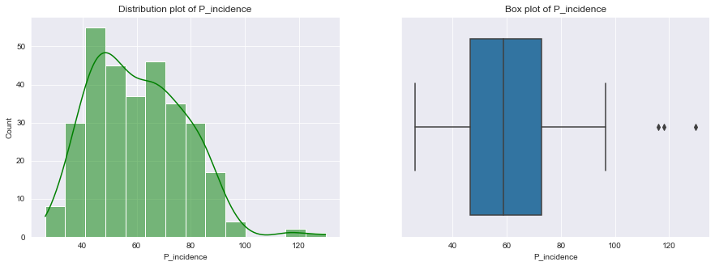

```
The number of outliers for P_incidence are 3
The distribution is skewed.
```

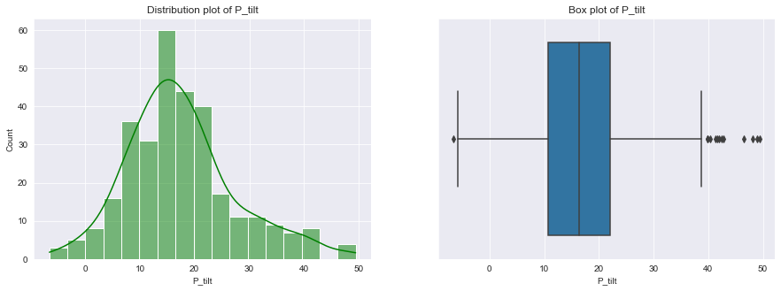

```
The number of outliers for P_tilt are 13
The distribution is skewed.
```

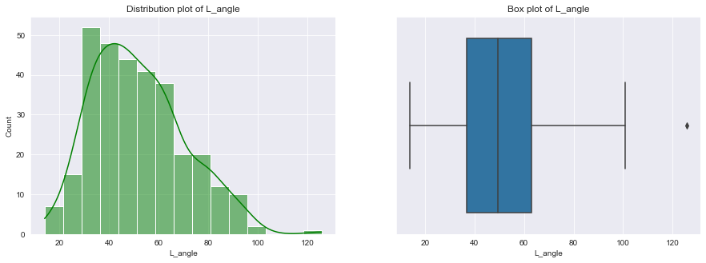

```
The number of outliers for L_angle are 1
The distribution is skewed.
```

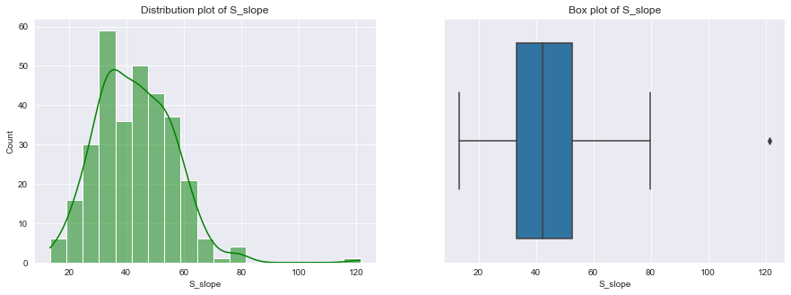

```
The number of outliers for S_slope are 1
The distribution is skewed.
```

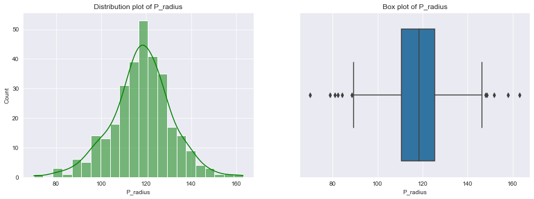

```
The number of outliers for P_radius are 11
The distribution is skewed.
```

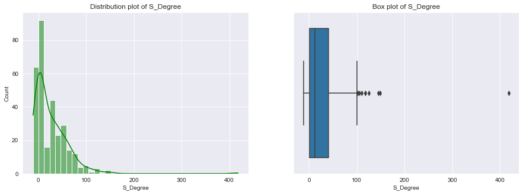

```
The number of outliers for S_Degree are 10
The distribution is skewed.
```

```python
outlier_columns = [] # initialising list to capture outlier columns

# plot the graphs - please do scroll
non_categorical_columns = dataset.columns[:-1]
for col_name in non_categorical_columns:
    plotHistogramAndBoxPlotWithOutliers(col_name,dataset)
```

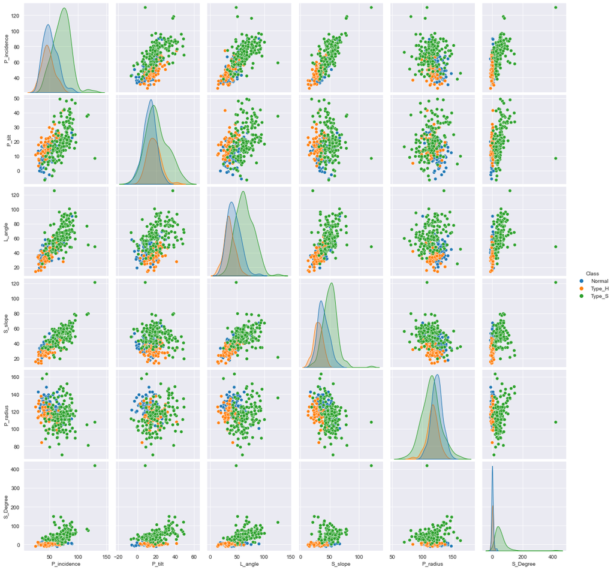

```python
sns.pairplot(dataset,diag_kind='kde',hue='Class')
plt.show()
```

There seems to be correlation between various input features which can also be confirmed by `correlation matrix` or a `heatmap`.

```python
corr = dataset.corr() # finding the correlation matrix
corr
```

|  | P_incidence | P_tilt | L_angle | S_slope | P_radius | S_Degree |
| --- | --- | --- | --- | --- | --- | --- |
| P_incidence | 1.000000 | 0.629199 | 0.717282 | 0.814960 | -0.247467 | 0.638743 |
| P_tilt | 0.629199 | 1.000000 | 0.432764 | 0.062345 | 0.032668 | 0.397862 |
| L_angle | 0.717282 | 0.432764 | 1.000000 | 0.598387 | -0.080344 | 0.533667 |
| S_slope | 0.814960 | 0.062345 | 0.598387 | 1.000000 | -0.342128 | 0.523557 |
| P_radius | -0.247467 | 0.032668 | -0.080344 | -0.342128 | 1.000000 | -0.026065 |
| S_Degree | 0.638743 | 0.397862 | 0.533667 | 0.523557 | -0.026065 | 1.000000 |

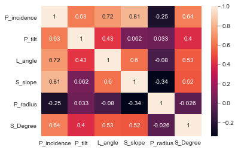

```python
# visualisation of correlation matrix
sns.heatmap(corr, annot=True)
plt.show()
```

## Data pre-processing

- Imputing values in `outlier_columns` by bringing values lower than `lower_fence` upto `lower_fence` and values higher than `upper_fence` upto `upper_fence`.
- I chose this approach of correcting outliers rather than imputimg to `mean`, `median` or `zero`, because those would change concentration of data and also outliers are more similar to the boundary elements.

```python
def pull_outliers_to_quartile_limits(df):
    for col_name in outlier_columns:
        lower_fence,upper_fence = calculateLowerAndUpperFence(col_name,df)
        print(f'The number of outliers for {col_name} before imputing are {number_of_outliers(col_name,lower_fence,upper_fence,df)}')

        col_index = df.columns.get_loc(col_name)
        # imputing values lower than lower fence equal to lower fence
        for row_index in np.where(df[col_name] < lower_fence)[0]:
            df.iloc[[ row_index],[col_index]] = lower_fence

        # imputing values higher than upper fence equal to upper fence
        for row_index in np.where(df[col_name] > upper_fence)[0]:
            df.iloc[[ row_index],[col_index]] = upper_fence

        print(f'The number of outliers for {col_name} after imputing are {number_of_outliers(col_name,lower_fence,upper_fence,df)}')
        print()
```

```python
pull_outliers_to_quartile_limits(dataset)
```

```
The number of outliers for P_incidence before imputing are 3
The number of outliers for P_incidence after imputing are 0

The number of outliers for P_tilt before imputing are 13
The number of outliers for P_tilt after imputing are 0

The number of outliers for L_angle before imputing are 1
The number of outliers for L_angle after imputing are 0

The number of outliers for S_slope before imputing are 1
The number of outliers for S_slope after imputing are 0

The number of outliers for P_radius before imputing are 11
The number of outliers for P_radius after imputing are 0

The number of outliers for S_Degree before imputing are 10
The number of outliers for S_Degree after imputing are 0
```

```python
# number of records for each target variable
dataset['Class'].value_counts()
```

```
Type_S    150
Normal    100
Type_H     60
Name: Class, dtype: int64
```

```python
def visualize_imbalance_in_target_variable(target_variable,col_name):
    # initialising subplots
    figure, ax = plt.subplots(nrows=1, ncols=2)

    # setting figure parameters
    figure.set_figheight(5)
    figure.set_figwidth(15)

    #setting axes titles
    ax[0].set_title(f'Pie Chart of {col_name}')
    ax[1].set_title(f'Count plot of {col_name}')

    # plotting the distribution
    target_variable.value_counts().plot.pie(ax=ax[0],autopct='%1.1f%%')
    sns.countplot(x=target_variable,ax=ax[1])

    plt.show()
```

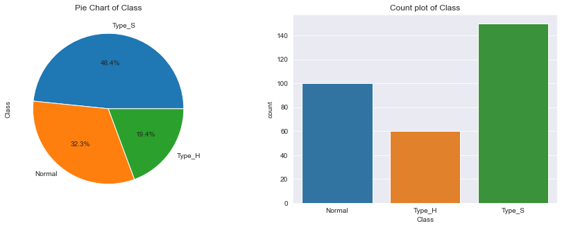

```python
# visualising number of records of each target variable
visualize_imbalance_in_target_variable(dataset['Class'],'Class')
```

#### Observations:

- From seeing number of records of each target variable, we can observe that that target variable/class is not balanced.
- Thus, `accuracy score` would not be a good metric for performance of the model.
- The context of the problem is medical field, so `recall or true positive rate or specificity` or even a balance of `precision and recall in F1 score` should be considered, because classifying a diseased person as healthy(`False Negative`) can be very lethal.

```python
label_encoder = LabelEncoder() # object of label encoder
dataset['Class'] = label_encoder.fit_transform(dataset['Class']) # transforming the data
dataset['Class'] = dataset['Class'].astype('category') # setting the target data type as categorical
# so by encoding we get three unique values for each class
dataset['Class'].unique()
```

```
[0, 1, 2]
Categories (3, int64): [0, 1, 2]
```

#### Splitting data into target and predictor atrributes

```python
X = np.array(dataset.drop(labels=['Class'],axis=1)) # independant attributes
y = np.array(dataset['Class'])  # target atrributes
```

#### Standard Scaling

As the independant features seem to be of different units and scales from above analysis, we convert/scale them normally.

```python
X_scaled = StandardScaler().fit_transform(X) # using a Standard Scaler
```

#### Splitting data into train and test sets

```python
# split data randomly into train and test sets
X_train, X_test, y_train, y_test = train_test_split(X_scaled,y,test_size=0.20,random_state=4)
```

```python
X_train.shape # number of records in predictor train set
```

```
(248, 6)
```

```python
X_test.shape # number of records in predictor test set
```

```
(62, 6)
```

## Model Tarining and testing

```python
actual_labels = ['Normal','Type_H','Type_S']
pred_labels = ['Predicted '+label for label in actual_labels]
```

```python
def plot_confusion_matrix(y_test,y_pred,lab,actual_labels,pred_labels): # function to plot confusion matrix
    cm = confusion_matrix(y_test,y_pred,labels=lab) # getting the confusion matrix
    cm_df = pd.DataFrame(cm, index=[i for i in actual_labels],columns=[i for i in pred_labels])

    plt.figure(figsize=(7,5))

    sns.heatmap(cm_df, annot=True,fmt='g')
    plt.show()
```

#### For `k = 3` nearest neighbors

```python
# KNN classifier for 3 nearest neighbours
knn = KNeighborsClassifier(n_neighbors=3)
```

```python
# fitting the model
knn.fit(X_train,y_train)
```

```
KNeighborsClassifier(n_neighbors=3)
```

```python
# predicting the response
y_pred = knn.predict(X_test)
```

```python
print(f'The accuracy of the model for k = 3 is {round(accuracy_score(y_test, y_pred)*100,3)}%')
```

```
The accuracy of the model for k = 3 is 80.645%
```

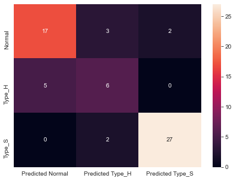

```python
plot_confusion_matrix(y_test,y_pred,[0,1,2],actual_labels,pred_labels) # calling the function
```

```python
print('The Classification Report is:')
print(classification_report(y_test,y_pred))
```

```
The Classification Report is:
              precision    recall  f1-score   support

           0       0.77      0.77      0.77        22
           1       0.55      0.55      0.55        11
           2       0.93      0.93      0.93        29

    accuracy                           0.81        62
   macro avg       0.75      0.75      0.75        62
weighted avg       0.81      0.81      0.81        62
```

#### Observations:

- There are 5 diseased people who have been predicted as Normal.
- The accuracy is 81% which is good.
- We are more concerned about diseased people being predicted as normal.

#### For `k = 5` nearest neighbors

```python
# KNN classifier for 5 nearest neighbours
knn = KNeighborsClassifier(n_neighbors=5)
```

```python
# fitting the model
knn.fit(X_train,y_train)
```

```
KNeighborsClassifier()
```

```python
# predicting the response
y_pred = knn.predict(X_test)
```

```python
print(f'The accuracy of the model for k = 5 is {round(accuracy_score(y_test, y_pred)*100,3)}%')
```

```
The accuracy of the model for k = 5 is 79.032%
```

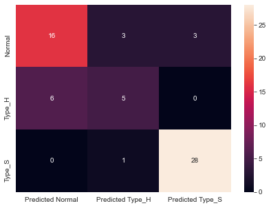

```python
plot_confusion_matrix(y_test,y_pred,[0,1,2],actual_labels,pred_labels) # calling the function
```

```python
print('The Classification Report is:')
print(classification_report(y_test,y_pred))
```

```
The Classification Report is:
              precision    recall  f1-score   support

           0       0.73      0.73      0.73        22
           1       0.56      0.45      0.50        11
           2       0.90      0.97      0.93        29

    accuracy                           0.79        62
   macro avg       0.73      0.72      0.72        62
weighted avg       0.78      0.79      0.78        62
```

#### Observations:

- There are 6 diseased people who have been predicted as Normal.
- The accuracy is 79% which is not that good.
- We are more concerned about diseased people being predicted as normal.

### Automating the task of finding the optimal K

The misclassifcation rate for that K should be low or the accuracy should be high.

```python
# taking odd number of neigbors
neighbors = np.arange(1,20,2)
```

```python
accuracy_scores = [] # initialise a list to store accuracy score for each K
for k in neighbors: # looping for each k and finding the accuracy
    # KNN classifier for k nearest neighbours
    knn = KNeighborsClassifier(n_neighbors=k)

    # fitting the model
    knn.fit(X_train,y_train)

    # predicting the response
    y_pred = knn.predict(X_test)

    # capturing accuracy score
    accuracy_scores.append(accuracy_score(y_test,y_pred))
```

#### Plotting Accuracy Score vs K

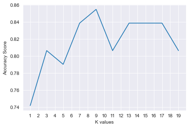

```python
plt.plot(neighbors, accuracy_scores)
plt.xticks(range(1,20))
plt.xlabel('K values')
plt.ylabel('Accuracy Score')

plt.show()
```

```python
optimal_k = neighbors[np.argmax(accuracy_scores)]
print(f'The optimal value of K for this model is {optimal_k}')
```

```
The optimal value of K for this model is 9
```

#### Thus, for `k = 9` nearest neighbors building the model

```
Accuracy on Training data: 1.0
Accuracy on Test data: 0.8225806451612904
The accuracy of the model for k = 9 is 82.258%
The recall score of the model for k = 9 is 82.258%
```

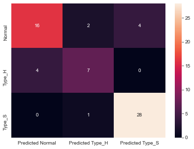

```
The Classification Report is:
              precision    recall  f1-score   support

           0       0.80      0.73      0.76        22
           1       0.70      0.64      0.67        11
           2       0.88      0.97      0.92        29

    accuracy                           0.82        62
   macro avg       0.79      0.78      0.78        62
weighted avg       0.82      0.82      0.82        62
```

```python
# KNN classifier for 9 nearest neighbours weighted on distance
knn = KNeighborsClassifier(n_neighbors=9,weights='distance')

# fitting the model
knn.fit(X_train,y_train)

# predicting the response
y_pred = knn.predict(X_test)

print('Accuracy on Training data:',knn.score(X_train, y_train) )
print('Accuracy on Test data:',knn.score(X_test, y_test) )

recall = recall_score(y_test, y_pred,average='weighted') # multi-class weighted recall score
print(f'The accuracy of the model for k = 9 is {round(accuracy_score(y_test, y_pred)*100,3)}%')
print(f'The recall score of the model for k = 9 is {round(recall*100,3)}%')

print()

plot_confusion_matrix(y_test,y_pred,[0,1,2],actual_labels,pred_labels) # calling the function

print()

print('The Classification Report is:')
print(classification_report(y_test,y_pred))
```

#### Trying different Regression models for finding the best model

- We can use `K-fold CV` technique

#### Importing the libraries

```python
from sklearn import model_selection

from sklearn.svm import SVC # Support Vector Classifier
```

#### Defining K-fold CV pipeline

```python
def k_fold_cv_pipeline():
    # model initialisations
    log_reg_model = LogisticRegression()  # Logistic regression Classifier

    KNN_model = KNeighborsClassifier(n_neighbors=optimal_k)  # KNN Classifier

    naive_bayes_model = GaussianNB()  # Gaussian Naive Bayes

    # Support Vector Machine Classifiers with different kernels
    svc_model_linear = SVC(kernel='linear',C=1,gamma=0.1)
    svc_model_rbf = SVC(kernel='rbf',degree=2,C=1,gamma=0.1)
    svc_model_poly  = SVC(kernel='poly',degree=2,C=1,gamma=0.1)

    # NOTE:: We can also manipulate C and gamma values

    # initialising models in key-value tuples
    models = []
    models.append(('LR', log_reg_model))
    models.append(('KNN', KNN_model))
    models.append(('NB', naive_bayes_model))
    if X.shape[0] < 1500: # use SVM only if the records are lesser, because it would be very high computations
        models.append(('SVM-linear', svc_model_linear))
        models.append(('SVM-poly', svc_model_poly))
        models.append(('SVM-rbf', svc_model_rbf))

    # evaluate each model in turn
    results = []
    model_names = []
    for model_name, model in models:
        kfold = model_selection.KFold(n_splits=10, random_state=4,shuffle=True)
        cv_results = model_selection.cross_val_score(model,X,y, cv=kfold, scoring='accuracy')
        results.append(cv_results)
        model_names.append(model_name)
        msg = model_name + ': ' + str(cv_results.mean()) + ' (' + str(cv_results.std()) +')'
        print(msg)

    # boxplot algorithm comparison
    fig = plt.figure()
    fig.suptitle('Algorithm Comparison')
    ax = fig.add_subplot(111)
    plt.boxplot(results)
    ax.set_xticklabels(model_names)
    plt.show()
```

```
LR: 0.8419354838709676 (0.07277751079147404)
KNN: 0.832258064516129 (0.05913000896717213)
NB: 0.8129032258064516 (0.06579380017539076)
SVM-linear: 0.8419354838709676 (0.061965718426769505)
SVM-poly: 0.8064516129032258 (0.0691858406113781)
SVM-rbf: 0.4806451612903226 (0.054838709677419335)
```

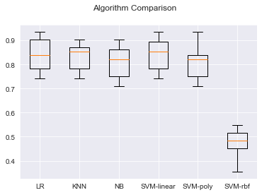

```python
k_fold_cv_pipeline() # using the k-fold-pipeline described above
```

### Conclusions and Observations:

- The above value of K-NN satisfies our cause of classifying diseased and normal people.
- The model doesn't have very high accuracy.
- The above factor may be influenced by high imbalance of data points for each target class. Hence, the model is also affected by `random_state` which may segregate data in a highly imbalanced fashion for differtent states. Hence, affecting the scores of each `train_test_split`.
- The above case study can be made better by getting balanced data points for each target class or also by using other classification algorithms like `SVC`.
- There is also high computational complexity imnvolved in K-NN.
- We can also use `SMOTE` to overcome target imbalance problem.

## +++++++++++++++++++++++++++++++++++++++++++++++++++++++++++++++++++++++++

# Part Two - Project based

`CONTEXT`: A bank X is on a massive digital transformation for all its departments. Bank has a growing customer base where majority of them are liability customers (depositors) vs borrowers (asset customers). The bank is interested in expanding the borrowers base rapidly to bring in more business via loan interests. A campaign that the bank ran in last quarter showed an average single digit conversion rate. Digital transformation being the core strength of the business strategy, marketing department wants to devise effective campaigns with better target marketing to increase the conversion ratio to double digit with same budget as per last campaign.

## Importing necessary libraries

```python
# NOTE:: Almost all the required libraries have been imported from above like numpy, pandas,
# seaborn, matplotlib, classifiers, model performance evaluators.

# for correcting imbalance in target variable
from imblearn.over_sampling import SMOTENC
```

## Importing all datasets and analysing

```python
data1 = pd.read_csv('Part2 - Data1.csv') # read from csv
data1.head() # see top 5 records
```

|  | ID | Age | CustomerSince | HighestSpend | ZipCode | HiddenScore | MonthlyAverageSpend | Level |
| --- | --- | --- | --- | --- | --- | --- | --- | --- |
| 0 | 1 | 25 | 1 | 49 | 91107 | 4 | 1.6 | 1 |
| 1 | 2 | 45 | 19 | 34 | 90089 | 3 | 1.5 | 1 |
| 2 | 3 | 39 | 15 | 11 | 94720 | 1 | 1.0 | 1 |
| 3 | 4 | 35 | 9 | 100 | 94112 | 1 | 2.7 | 2 |
| 4 | 5 | 35 | 8 | 45 | 91330 | 4 | 1.0 | 2 |

```python
data1.shape # analysing the shape of dataset
```

```
(5000, 8)
```

```python
data2 = pd.read_csv('Part2 -Data2.csv') # read from csv
data2.head() # see top 5 records
```

|  | ID | Mortgage | Security | FixedDepositAccount | InternetBanking | CreditCard | LoanOnCard |
| --- | --- | --- | --- | --- | --- | --- | --- |
| 0 | 1 | 0 | 1 | 0 | 0 | 0 | NaN |
| 1 | 2 | 0 | 1 | 0 | 0 | 0 | NaN |
| 2 | 3 | 0 | 0 | 0 | 0 | 0 | NaN |
| 3 | 4 | 0 | 0 | 0 | 0 | 0 | NaN |
| 4 | 5 | 0 | 0 | 0 | 0 | 1 | NaN |

```python
data2.shape # analysing the shape of dataset
```

```
(5000, 7)
```

#### Observations:

From importing data from the two CSV, it looks like the features are split between the two CSV.

- The number of records in both data sets is 5000.
- The common feature between the two is `ID`.
- Doing an `inner` merge on `ID` will combine the two data sets, by combining records on `ID`.
- We can also do a concat on `axis=1` but it won't be a good idea, because:
  - we would need to drop a duplicated `ID` column.
  - the records might not be in same sequence of `ID` between the two data sets.

## Merging all datasets

We can confirm if the `ID` are same in both sets by either checking the `shape` of meregd dataset or by checking length on logical selection.

```python
len(data1[data1['ID'] == data2['ID']].index)
```

```
5000
```

```python
# merge on common ID
bank_dataset = pd.merge(left=data1,right=data2,how='inner',on='ID')
bank_dataset.head() # checking top 5 records
```

|  | ID | Age | CustomerSince | HighestSpend | ZipCode | HiddenScore | MonthlyAverageSpend | Level | Mortgage | Security | FixedDepositAccount | InternetBanking | CreditCard | LoanOnCard |
| --- | --- | --- | --- | --- | --- | --- | --- | --- | --- | --- | --- | --- | --- | --- |
| 0 | 1 | 25 | 1 | 49 | 91107 | 4 | 1.6 | 1 | 0 | 1 | 0 | 0 | 0 | NaN |
| 1 | 2 | 45 | 19 | 34 | 90089 | 3 | 1.5 | 1 | 0 | 1 | 0 | 0 | 0 | NaN |
| 2 | 3 | 39 | 15 | 11 | 94720 | 1 | 1.0 | 1 | 0 | 0 | 0 | 0 | 0 | NaN |
| 3 | 4 | 35 | 9 | 100 | 94112 | 1 | 2.7 | 2 | 0 | 0 | 0 | 0 | 0 | NaN |
| 4 | 5 | 35 | 8 | 45 | 91330 | 4 | 1.0 | 2 | 0 | 0 | 0 | 0 | 1 | NaN |

```python
bank_dataset.shape # checking number of records and features in the combined dataset
```

```
(5000, 14)
```

## Data Cleansing

```python
bank_dataset.info() # analyse the data types, number of nulls in each column
```

```
<class 'pandas.core.frame.DataFrame'>
Int64Index: 5000 entries, 0 to 4999
Data columns (total 14 columns):
 #   Column               Non-Null Count  Dtype
---  ------               --------------  -----
 0   ID                   5000 non-null   int64
 1   Age                  5000 non-null   int64
 2   CustomerSince        5000 non-null   int64
 3   HighestSpend         5000 non-null   int64
 4   ZipCode              5000 non-null   int64
 5   HiddenScore          5000 non-null   int64
 6   MonthlyAverageSpend  5000 non-null   float64
 7   Level                5000 non-null   int64
 8   Mortgage             5000 non-null   int64
 9   Security             5000 non-null   int64
 10  FixedDepositAccount  5000 non-null   int64
 11  InternetBanking      5000 non-null   int64
 12  CreditCard           5000 non-null   int64
 13  LoanOnCard           4980 non-null   float64
dtypes: float64(2), int64(12)
memory usage: 585.9 KB
```

```python
# null values can also be checked as
bank_dataset.isnull().sum()
```

```
ID                      0
Age                     0
CustomerSince           0
HighestSpend            0
ZipCode                 0
HiddenScore             0
MonthlyAverageSpend     0
Level                   0
Mortgage                0
Security                0
FixedDepositAccount     0
InternetBanking         0
CreditCard              0
LoanOnCard             20
dtype: int64
```

#### Observations:

- We have 5000 records out of which only 20 records are `null`, so we can safely drop those.
- but before we drop any record, or make any manipulation, we should make a copy of the original dataset.
- From the column description and `info`, it seems some columns should have data type as `categorical` but are `int`, sow ould need to change the data type.
- `ID` is just an identifier of the customer, so will not have an impact on the model, so we can drop it.
- `ZipCode` could be used for deciding the area customer lives in and what is the standard of living in that area, but we would need additional data for that, so this attribute can also be dropped.

```python
bank_dataset_copy = bank_dataset.copy() # copying dataset for manipulation
```

```python
bank_dataset_copy.dropna(inplace=True) # dropping all null values
bank_dataset_copy.isnull().sum().any() # checking if all null values are dropped
```

```
False
```

```python
# changing data type of categorical columns
categorical_columns = ['HiddenScore','Level','Security','FixedDepositAccount', 'InternetBanking', 'CreditCard', 'LoanOnCard']
for col_name in categorical_columns:
    bank_dataset_copy[col_name] = bank_dataset_copy[col_name].astype('category')
```

```python
# dropping non-impactful columns
bank_dataset_copy.drop(axis=1,inplace=True,columns=['ID','ZipCode'])
```

## Data Analysis & Visualisation

```python
bank_dataset_copy.describe(include='all').transpose()
```

|  | count | unique | top | freq | mean | std | min | 25% | 50% | 75% | max |
| --- | --- | --- | --- | --- | --- | --- | --- | --- | --- | --- | --- |
| Age | 4980.0 | NaN | NaN | NaN | 45.352610 | 11.464212 | 23.0 | 35.0 | 45.0 | 55.000 | 67.0 |
| CustomerSince | 4980.0 | NaN | NaN | NaN | 20.117671 | 11.468716 | -3.0 | 10.0 | 20.0 | 30.000 | 43.0 |
| HighestSpend | 4980.0 | NaN | NaN | NaN | 73.852410 | 46.070090 | 8.0 | 39.0 | 64.0 | 98.000 | 224.0 |
| HiddenScore | 4980.0 | 4.0 | 1.0 | 1466.0 | NaN | NaN | NaN | NaN | NaN | NaN | NaN |
| MonthlyAverageSpend | 4980.0 | NaN | NaN | NaN | 1.939536 | 1.750006 | 0.0 | 0.7 | 1.5 | 2.525 | 10.0 |
| Level | 4980.0 | 3.0 | 1.0 | 2089.0 | NaN | NaN | NaN | NaN | NaN | NaN | NaN |
| Mortgage | 4980.0 | NaN | NaN | NaN | 56.589759 | 101.836758 | 0.0 | 0.0 | 0.0 | 101.000 | 635.0 |
| Security | 4980.0 | 2.0 | 0.0 | 4460.0 | NaN | NaN | NaN | NaN | NaN | NaN | NaN |
| FixedDepositAccount | 4980.0 | 2.0 | 0.0 | 4678.0 | NaN | NaN | NaN | NaN | NaN | NaN | NaN |
| InternetBanking | 4980.0 | 2.0 | 1.0 | 2974.0 | NaN | NaN | NaN | NaN | NaN | NaN | NaN |
| CreditCard | 4980.0 | 2.0 | 0.0 | 3514.0 | NaN | NaN | NaN | NaN | NaN | NaN | NaN |
| LoanOnCard | 4980.0 | 2.0 | 0.0 | 4500.0 | NaN | NaN | NaN | NaN | NaN | NaN | NaN |

#### Observations:

- From the above table we can figure out the `5-point summary` of each non-categorical variable.
- The ditributions and outliers of each non-categorical variable can be visualised using `histplot` and `boxplot`.

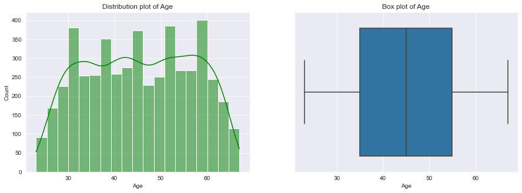

```
The number of outliers for Age are 0
```

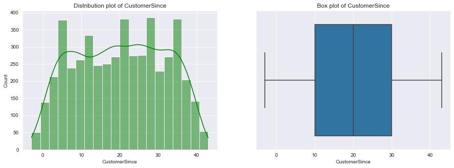

```
The number of outliers for CustomerSince are 0
```

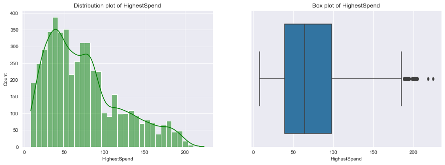

```
The number of outliers for HighestSpend are 96
The distribution is skewed.
```

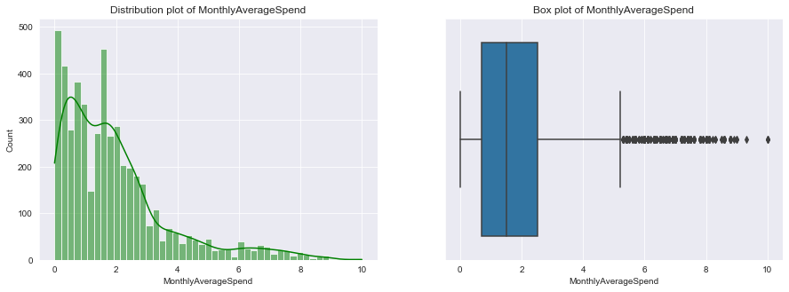

```
The number of outliers for MonthlyAverageSpend are 324
The distribution is skewed.
```

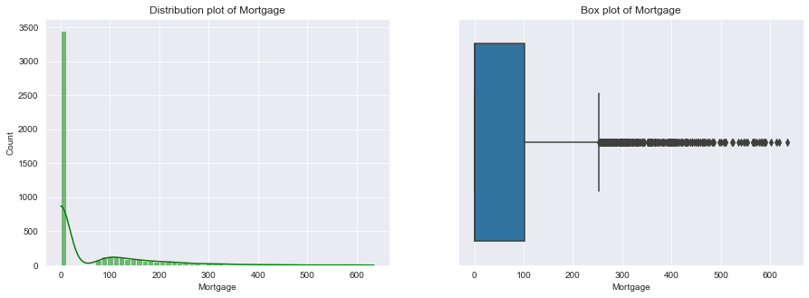

```
The number of outliers for Mortgage are 291
The distribution is skewed.
```

```python
outlier_columns = [] # initialising list to capture outlier columns

# plot the graphs - please do scroll
non_categorical_columns = ['Age','CustomerSince','HighestSpend','MonthlyAverageSpend','Mortgage']
for col_name in non_categorical_columns:
    plotHistogramAndBoxPlotWithOutliers(col_name,bank_dataset_copy)
```

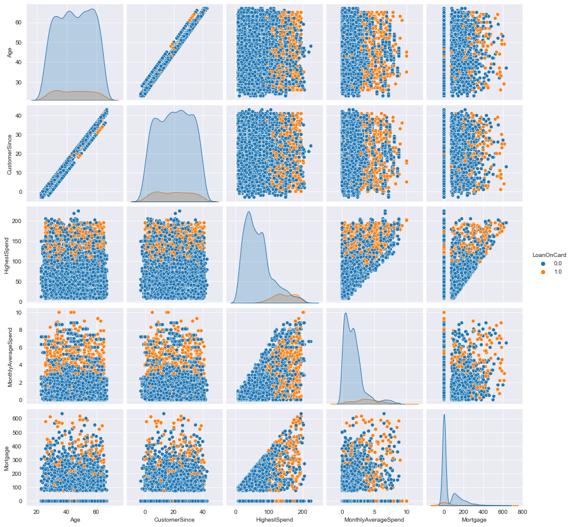

```python
sns.pairplot(data=bank_dataset_copy,diag_kind='kde',hue='LoanOnCard')
plt.show()
```

- There seems to be `high` correlation between `Age` and `Since` and moderate correlation between `MonthlyAverageSpend` and `HighestSpend` input features which can also be confirmed by `correlation matrix` or a `heatmap`.

```python
corr = bank_dataset_copy.corr() # correlation matrix
corr
```

|  | Age | CustomerSince | HighestSpend | MonthlyAverageSpend | Mortgage |
| --- | --- | --- | --- | --- | --- |
| Age | 1.000000 | 0.994208 | -0.054951 | -0.051896 | -0.013272 |
| CustomerSince | 0.994208 | 1.000000 | -0.046092 | -0.049918 | -0.011380 |
| HighestSpend | -0.054951 | -0.046092 | 1.000000 | 0.646109 | 0.207236 |
| MonthlyAverageSpend | -0.051896 | -0.049918 | 0.646109 | 1.000000 | 0.110275 |
| Mortgage | -0.013272 | -0.011380 | 0.207236 | 0.110275 | 1.000000 |

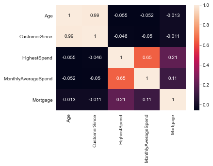

```python
# visualising the correlation matrix
sns.heatmap(data=corr,annot=True)
plt.show()
```

## Data pre-processing

- Imputing values in `outlier_columns` by bringing values lower than `lower_fence` upto `lower_fence` and values higher than `upper_fence` upto `upper_fence`.
- I chose this approach of correcting outliers rather than imputimg to `mean`, `median` or `zero`, because those would change concentration of data and also outliers are more similar to the boundary elements.

```python
pull_outliers_to_quartile_limits(bank_dataset_copy)
```

```
The number of outliers for HighestSpend before imputing are 96
The number of outliers for HighestSpend after imputing are 0

The number of outliers for MonthlyAverageSpend before imputing are 324
The number of outliers for MonthlyAverageSpend after imputing are 0

The number of outliers for Mortgage before imputing are 291
The number of outliers for Mortgage after imputing are 0
```

#### Splitting data into predictor and target variables

```python
X = bank_dataset_copy.drop(axis=1,columns=['LoanOnCard']) # predictor variables
y = bank_dataset_copy[['LoanOnCard']] # target variables
```

#### Checking target classes balance

```python
y['LoanOnCard'].value_counts() # using value of counts for various values
```

```
0.0    4500
1.0     480
Name: LoanOnCard, dtype: int64
```

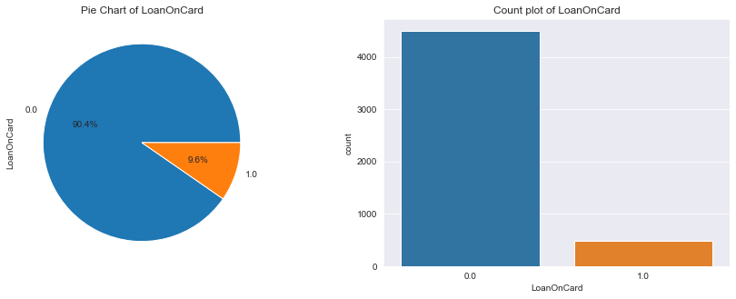

```python
# visualising imbalance in target variables
visualize_imbalance_in_target_variable(y['LoanOnCard'],'LoanOnCard')
```

#### Observations:

- As seen from above analysis, there is huge imbalance between the classes in the target variable.
- This should be fixed by bringing in balanced data for the target classes or there can be some techniques applied before building the model. If we do not treat the data before model building, the model will be more inclined to one of the target class than the other. Some techniques used are:
  - Use metrics like `precision`, `recall`, `F1-score`.
  - `Over-sampling` tries to balance dataset by increasing the size of rare samples, rather than getting rid of abundant samples using `SMOTE (Synthetic Minority Over-Sampling Technique)`.
  - `Under-sampling` balances the dataset by reducing the size of the abundant class.
- We will use `over-sampling` and only on `train data` because:
  - we don't want to loose on data that would be helpful for classification.
  - we shouldn't be `over-sampling` all the data, because model performance is judged on `test or unseen data`.

#### Splitting into `train` and `test` data

```python
# splitting data into train:test as 70:30
X_train, X_test, y_train, y_test = train_test_split(X,y,test_size=0.30,random_state=4)
```

#### Fixing imbalance in target data

```python
cat_col_index = [] # initialise a list told categorical column index
for column in categorical_columns:
    # get index of each categorical column
    if column != 'LoanOnCard': # skip target class
        cat_col_index.append(bank_dataset_copy.columns.get_loc(column))
```

```python
# fixing imbalance of data using SMOTE for train data
smote_nc = SMOTENC(categorical_features=cat_col_index,random_state=4)
X_train_res, y_train_res = smote_nc.fit_resample(X_train, y_train)
```

```python
print('Before applying SMOTE:')
print(y_train.value_counts())
```

```
Before applying SMOTE:
LoanOnCard
0.0           3146
1.0            340
dtype: int64
```

```python
print('After applying SMOTE:')
print(y_train_res.value_counts())
```

```
After applying SMOTE:
LoanOnCard
0.0           3146
1.0           3146
dtype: int64
```

## Model tarining and testing

### Logistic Regression

```python
# initialise classifier
logit_reg = LogisticRegression()

# fit on train data
logit_reg.fit(X_train_res,y_train_res)

# predict on test data
y_pred = logit_reg.predict(X_test)

print(f'Accuracy on Training data {round(logit_reg.score(X_train_res, y_train_res),3)*100}%')
print(f'Accuracy on Test data {round(logit_reg.score(X_test, y_test),2)*100}%')
```

```
Accuracy on Training data 91.4%
Accuracy on Test data 90.0%
```

```python
actual_labels = ['Actual 0','Actual 1']
pred_labels =['Predicted 0', 'Predicted 1']
```

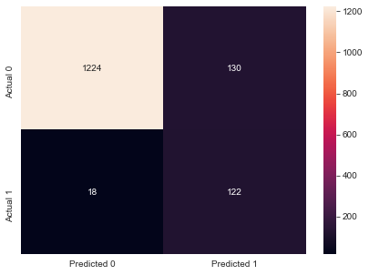

```python
plot_confusion_matrix(y_test,y_pred,[0,1],actual_labels,pred_labels)
```

```python
print('The Classification Report is:')
print(classification_report(y_test,y_pred))
```

```
The Classification Report is:
              precision    recall  f1-score   support

         0.0       0.99      0.90      0.94      1354
         1.0       0.48      0.87      0.62       140

    accuracy                           0.90      1494
   macro avg       0.73      0.89      0.78      1494
weighted avg       0.94      0.90      0.91      1494
```

```python
recall = recall_score(y_test,y_pred)
print(f'The Recall Score of the model is {round(recall,3)*100}%')
```

```
The Recall Score of the model is 87.1%
```

#### Observations:

- Accuracy of the model is very good 90%.
- Precision for `class 1` is bit low, but the overall recall is good.

### Naive Bayes Classifier

```python
# initialise classifier
nb_classifier = GaussianNB()

# fit on train data
nb_classifier.fit(X_train_res,y_train_res)

# predict on test data
y_pred = nb_classifier.predict(X_test)

print(f'Accuracy on Training data {round(nb_classifier.score(X_train_res, y_train_res),2)*100}%')
print(f'Accuracy on Test data {round(nb_classifier.score(X_test, y_test),2)*100}%')
```

```
Accuracy on Training data 90.0%
Accuracy on Test data 88.0%
```

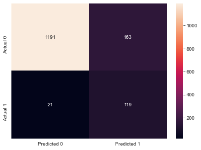

```python
plot_confusion_matrix(y_test,y_pred,[0,1],actual_labels,pred_labels)
```

```python
print('The Classification Report is:')
print(classification_report(y_test,y_pred))
```

```
The Classification Report is:
              precision    recall  f1-score   support

         0.0       0.98      0.88      0.93      1354
         1.0       0.42      0.85      0.56       140

    accuracy                           0.88      1494
   macro avg       0.70      0.86      0.75      1494
weighted avg       0.93      0.88      0.89      1494
```

```python
recall = recall_score(y_test,y_pred)
print(f'The Recall Score of the model is {round(recall,3)*100}%')
```

```
The Recall Score of the model is 85.0%
```

#### Observations:

- Accuracy of the model is very good 88%.
- Precision for `class 1` is bit low, but the overall recall is good.

#### Trying different Regression models for finding the best model

- We can use `K-fold CV` technique

#### Importing the libraries

All necesary libraries are already imported

```
LR: 0.9516064257028113 (0.00997771746891956)
KNN: 0.9116465863453816 (0.016800402139238464)
NB: 0.8959839357429719 (0.011770562963656894)
```

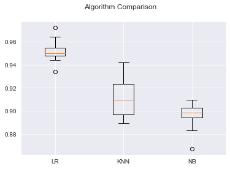

```python
k_fold_cv_pipeline() # using the k-fold-pipeline described above
```

### Observations & Conclusions:

- The dataset has target variable highly imbalanced.
- We should collect balanced data or use balancing techniques.
- Logistic Regression model satisfies our cause of classifying the data as it has good accuracy and recall score andperformed well in training and test data.